# Transcriptome-wide binding of Rrm4 indentified through iCLIP2

Author

Srimeenakshi Sankaranarayanan

Published

June 12, 2026

This report focuses on the identification of transcriptome-wide binding sites of full-length Rrm4. The main aim of this study is to evaluate the efficiency of the iCLIP2 protocol in resolving RNA–protein interactions, in comparison with the previously established iCLIP protocol.

To this end, iCLIP2 analysis was performed using full-length Rrm4 using five biological replicates. The resulting RNA-sequencing reads were pre-processed by Anke Busch at IMB, Mainz. Crosslink sites were then identified from the mapped reads using pureCLIP.

In this report, the BindingSiteFinder package is used to identify Rrm4 binding sites across the transcriptome.

```r
## libraries
library(BSgenome.Umaydis.ENSMBL.UM1) # forged tomato genome
library(ggplot2)
library(BindingSiteFinder)
library(rtracklayer)
library(ComplexHeatmap)
library(GenomicFeatures)
library(forcats)
library(tidyr)
library(dplyr)
library(tidyverse)
library(GenomicRanges)
library(magick)
library(magrittr)
library(gridExtra)
library(IRanges)
library(Biostrings)
#library(ggpmisc)
library(ggrepel)
library(ggpubr)
library(viridis)
library(reshape2)
library(gprofiler2)
library(ggsci)
library(GGally)
library(ggplotify)
library(GetoptLong)
library(tidyHeatmap)
```

```r
## theme for ggplot
my_theme = theme_set(theme_bw() +
          theme(axis.text = element_text(size = 10, colour="black"),
                axis.title = element_text(size=12, colour="black"),
                axis.ticks=element_line(color="black"),
                axis.ticks.length=unit(.15, "cm"),
                panel.border=element_rect(color="black", fill = NA),
                panel.background = element_blank(),
                plot.background = element_blank(),
                legend.text = element_text(size=10),
                legend.position = "bottom",
                aspect.ratio = 1/1)
)
```

```r
## load gene annotation
gnsN = readRDS("~/Documents/Bioinfo_analysis/iCLIP_course/diffRNA_binding/Annotation_preparation/gns.rds")

trl = readRDS("~/Documents/Bioinfo_analysis/iCLIP_course/diffRNA_binding/Annotation_preparation/trl.rds")
```

```r
## color to use
# Transcript region
u3 = "#D41D1F"
cd= "#FF9D9A"
u5 = "#E15759"
In  = "#D3D3D3"
```

## 1 Prepare binding sites

```r
## import the pureCLIP data

# folder where the pureCLIP output and bw files are found
my.path.rrm4 = "~/Documents/Bioinfo_analysis/iCLIP_course/datasets/imb_koenig_2021_11_stoffel_iCLIP_ustilago_Rrm4/PUREclip_peaks"
# pureClip path
peaksInitial = paste0(my.path.rrm4,"/sites.imb_koenig_2021_11_Rrm4G.v3.duprm.bam.bed")

#import the crosslink sites identified by pureCLIP
peaksInitial= import(con = peaksInitial,
                     format = "BED",
                     extraCols=c("additionalScores" = "character"))
peaksInitial = keepStandardChromosomes(peaksInitial, pruning.mode = "coarse")
```

```r
## import the bw files
# bw files from the "+" strand
plus_bw = list.files(my.path.rrm4,
                     pattern= "plus.bw$",
                     full.names = T)

# bw files from the "-" strand
minus_bw=list.files(my.path.rrm4,
                    pattern= "minus.bw$",
                    full.names = T)

# define metadata table
meta.file.rrm4= data.frame(
  name = "Rrm4G",
  id=paste0("rep", 1:5),
  condition= factor(rep("rrm4G", 5)),
  clPlus= plus_bw,
  clMinus=minus_bw
)

# Make BindingSiteFinder object
bdsWT.initial = BSFDataSetFromBigWig(ranges = peaksInitial,
                                     meta = meta.file.rrm4)
```

## 2 Define binding sites

As identified in Olgeiser et.al (2019), the Rrm4 binding site width will be set to 9-nt. This allows direct comparison of the efficiency of two different iCLIP protocol in resolving Rrm4-RNA interaction.

```r
## resolve overlapping bs

# resolve overlapping transcript biotypes using hierarchy
rule.gene = c("tRNA", "protein_coding", "rRNA", "snRNA", "snoRNA")

# binding site definition
bdsWT.merge = BSFind(bdsWT.initial,
                     anno.genes = gnsN,
                     anno.transcriptRegionList = trl,
                     bsSize = 9,
                     cutoff.geneWiseFilter = 0.1,
                     cutoff.globalFilter = 0.05,
                     merge.minWidth = 2,
                     merge.minClSites = 2,
                     merge.minCrosslinks = 2,
                     repro.cutoff=0.05,
                     repro.nReps = 4,
                     overlaps.geneAssignment = "hierarchy",
                     overlaps.rule.geneAssignment = rule.gene,
                     match.geneType = "gene_biotype",
                     match.geneName = "gene_id")
```

First, I want to determine whether defining binding sites after filtering out poor crosslinking events and accounting for reproducibility improves the overall consistency between replicates.

**before reproducibility filter**

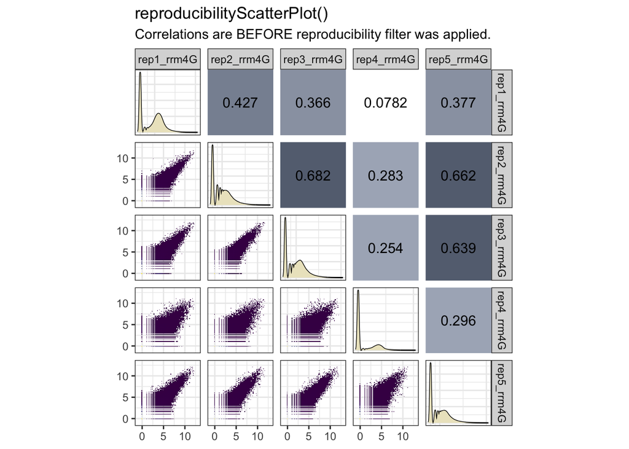

```r
reproducibilityScatterPlot(bdsWT.initial, quiet = FALSE)
```

**after reproducibility filter**

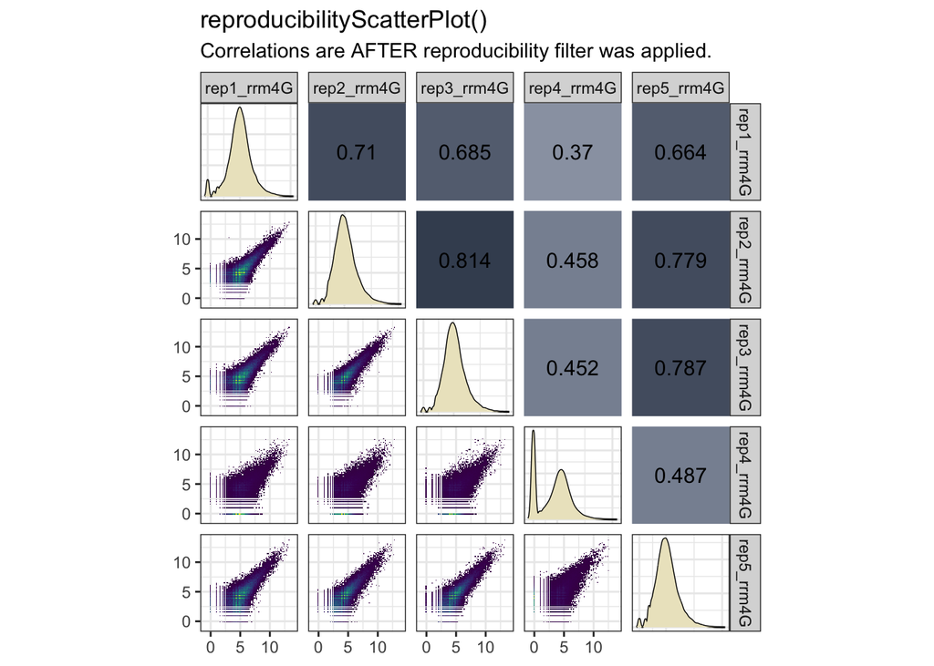

```r
reproducibilityScatterPlot(bdsWT.merge, quiet = FALSE)
```

Next, I want to check the reproducibility of identified binding sites across the five replicates.

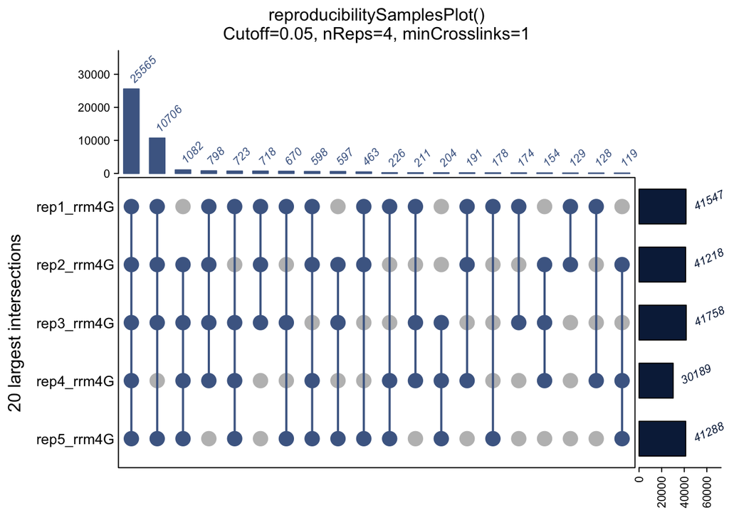

```r
## check binding site reproducibility
reproducibilitySamplesPlot(bdsWT.merge)
```

This analysis revealed that the identified binding sites were highly reproducible, with majority of them overlapping with at least 4 out of 5 replicates.

## 3 Analysing binding sites of full-length Rrm4

Next, I will assess whether Rrm4 binding sites are enriched in specific transcript region.

**Rrm4 binding site strength vs transcript region**

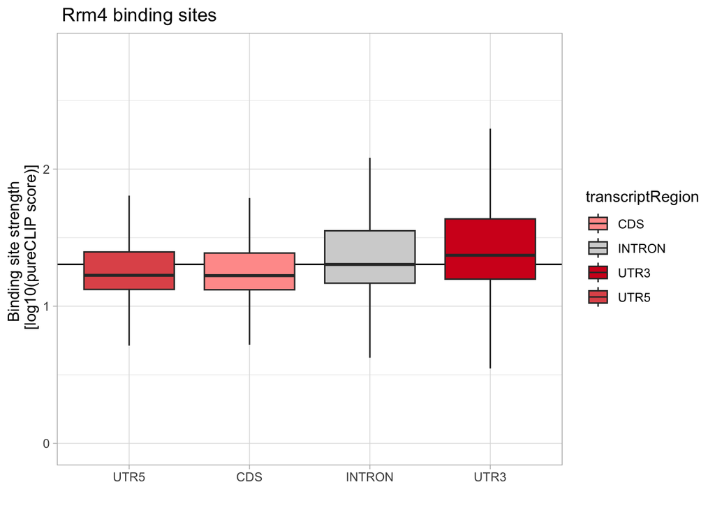

```r
# get GRanges
bdsWT.gr= getRanges(bdsWT.merge)

bdsWT.df = bdsWT.gr %>%
  data.frame(.) %>%
  .[,c(12:14)] %>%
  filter(.,!transcriptRegion=="OTHER")

# 20.1833 median of all the scores
ggplot(bdsWT.df, aes(x= factor(transcriptRegion,
                                         levels = c("UTR5", "CDS", "INTRON", "UTR3")),
                               y=log10(score),
                               fill=transcriptRegion))+
          geom_hline(yintercept = log10(20.1833))+
          geom_boxplot(outlier.shape = NA)+
          labs(title = " Rrm4 binding sites",
               x= "",
               y= "Binding site strength \n [log10(pureCLIP score)]")+
          scale_fill_manual(values = c("CDS"=cd, "INTRON"=In, "UTR3"=u3, "UTR5"=u5))+
          theme(legend.position = "None")+
          theme_light()
```

**fraction of binding sites in transcript region**

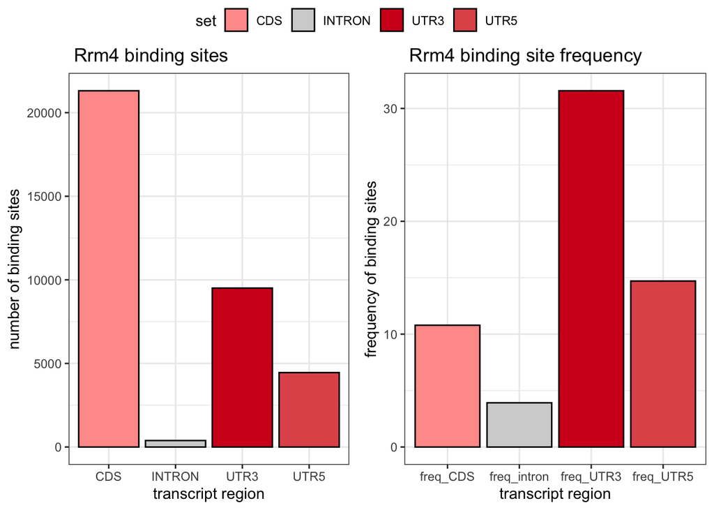

```r
## get the binding site count across transcript region across all genes
bdsWT.df = bdsWT.gr %>%
  data.frame(.) %>%
  .[,c(12)] %>% table(.)  %>%
  as.data.frame.array(.) %>%
  rownames_to_column(.) %>%
  set_colnames(.,c("set", "value")) %>%
  .[-3,]

# ggplot
Bstr_all.pl = ggplot(bdsWT.df, aes(x=set, y=value, fill=set))+
          geom_bar(stat="identity",  color="black")+
          labs(title = " Rrm4 binding sites",
               x= "transcript region",
               y= "number of binding sites")+
          scale_fill_manual(values = c("CDS"=cd, "INTRON"=In, "UTR3"=u3, "UTR5"=u5))+
          theme(legend.position = "None")+
          theme_bw()


## get the binding site frequency across each transcript region within each gene
bdsWT.df = bdsWT.gr %>%
  data.frame(.) %>%
  .[,c(9,12)] %>%
  .[!(is.na(.$geneID)),] %>%
  table(.)  %>%
  as.data.frame.array(.) %>%
  rownames_to_column(., "gene_id") %>%.[,-4]


# Normalize the binding site count across transcript region with its width for each gene

bdsWT.df$CDS_length = lookup::lookup(bdsWT.df$gene_id, gnsN$gene_id, width(gnsN)) #CDS
bdsWT.df$UTR3_length = 300 #UTR3
bdsWT.df$UTR5_length = 300  #UTR5
bdsWT.df$int_length = median(width(trl$intron)) #Intron

# caluclation of the fraction
bdsWT.df$freq_CDS = bdsWT.df$CDS/bdsWT.df$CDS_length
bdsWT.df$freq_intron = bdsWT.df$INTRON/bdsWT.df$int_length
bdsWT.df$freq_UTR3 = bdsWT.df$UTR3/bdsWT.df$UTR3_length
bdsWT.df$freq_UTR5= bdsWT.df$UTR5/bdsWT.df$UTR5_length

bdsWT.df = bdsWT.df[,c(10:13)]

bdsWT.df = colSums(bdsWT.df) %>%
  as.data.frame(.) %>%
  rownames_to_column(.) %>%
  set_colnames(.,c("set", "value"))

Bstr_freq.pl = ggplot(bdsWT.df, aes(x=set, y=value, fill=set))+
          geom_bar(stat="identity", color="black")+
          labs(title = " Rrm4 binding site frequency",
               x= "transcript region",
               y= "frequency of binding sites")+
         scale_fill_manual(values = c("freq_CDS"=cd, "freq_intron"=In, "freq_UTR3"=u3, "freq_UTR5"=u5))+
          theme(legend.position = "None")+
          theme_bw()


ggarrange(Bstr_all.pl, Bstr_freq.pl, ncol=2, common.legend = TRUE)
```

Overall, a greater number of Rrm4 binding sites were identified within the CDS region. However, frequency analysis revealed that binding sites occurred more frequently in the 3′ UTR than in the CDS.